# Introdução ao Tidyverse

# *Começando o eixo y do zero*

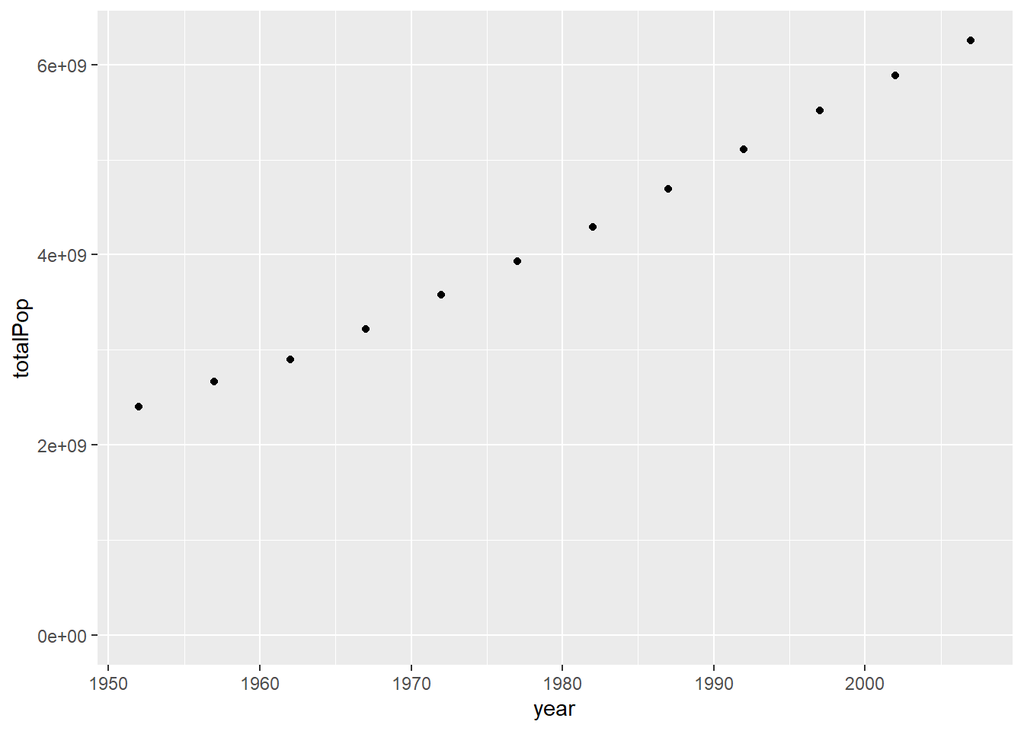

```r
ggplot(by_year, aes(x = year, y = totalPop)) +
      geom_point() +
      expand_limits(y=0)
```

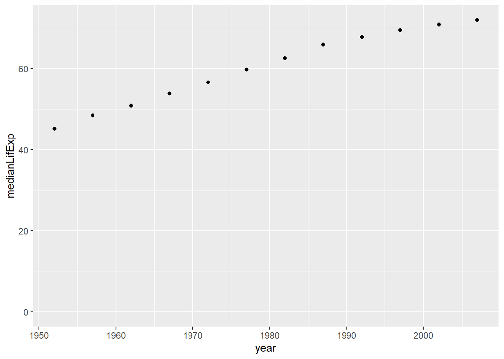

```r
ggplot(by_year, aes(x = year, y = medianLifExp)) +
      geom_point() +
      expand_limits(y=0)
```

# *Sumarizando por ano e continente*

```r
by_year_continent <- gapminder %>%
                  group_by(year, continent) %>%
                  summarize(totalPop = sum(as.numeric(pop)),
                  meanLifeExp = mean(lifeExp))
by_year_continent
```

```
## # A tibble: 60 x 4
## # Groups:   year [12]
##     year continent   totalPop meanLifeExp
##    <int> <fct>          <dbl>       <dbl>
##  1  1952 Africa     237640501        39.1
##  2  1952 Americas   345152446        53.3
##  3  1952 Asia      1395357351        46.3
##  4  1952 Europe     418120846        64.4
##  5  1952 Oceania     10686006        69.3
##  6  1957 Africa     264837738        41.3
##  7  1957 Americas   386953916        56.0
##  8  1957 Asia      1562780599        49.3
##  9  1957 Europe     437890351        66.7
## 10  1957 Oceania     11941976        70.3
## # ... with 50 more rows
```

Vamos agora visualizar “by_year_continent” pela estetica de cores

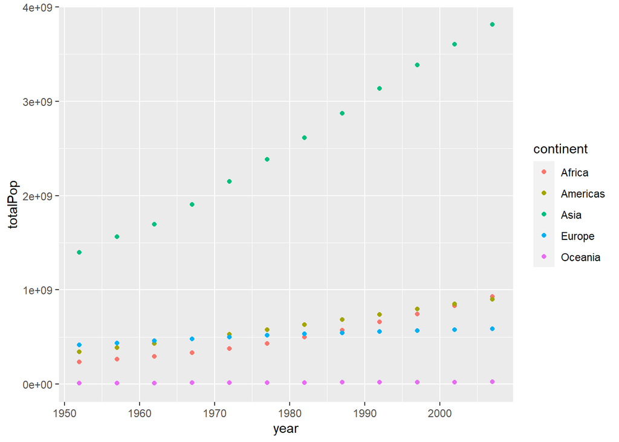

```r
ggplot(by_year_continent, aes(x = year, y = totalPop, color = continent)) +
      geom_point() +
      expand_limits(y=0)
```

Exercicio

```r
# Summarize medianGdpPercap within each continent within each year: by_year_continent
by_year_continent <- gapminder %>%
                  group_by(year, continent) %>%
                  summarize(medianGdpPercap = median(gdpPercap))
```

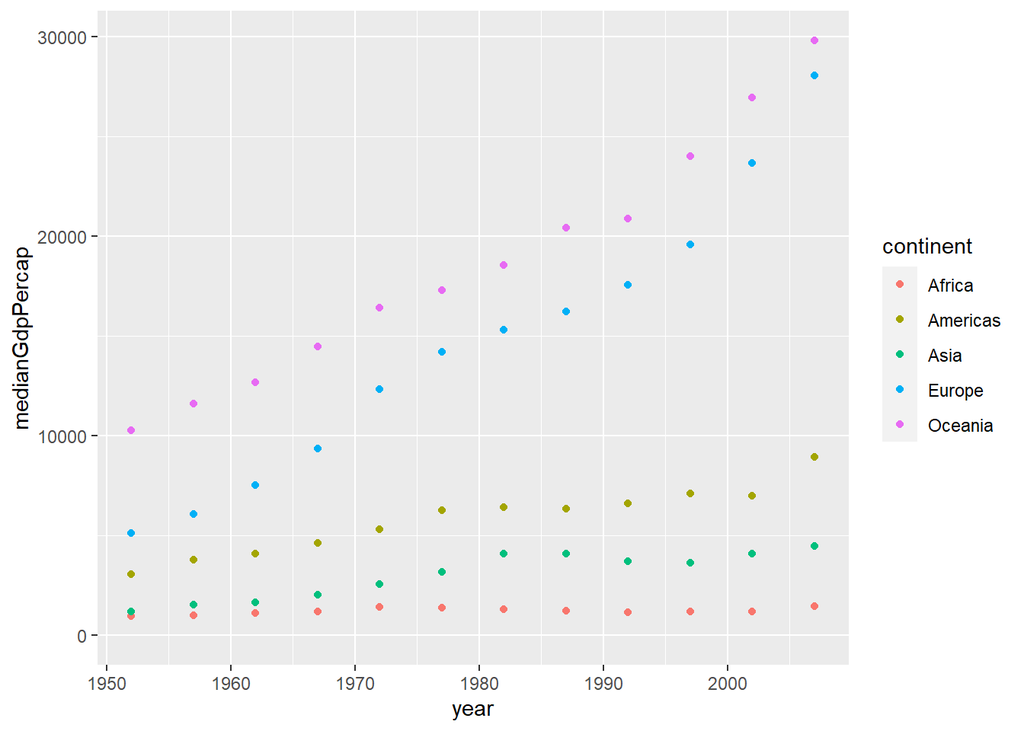

```r
# Plot the change in medianGdpPercap in each continent over time
ggplot(by_year_continent, aes(x = year, y = medianGdpPercap, color = continent)) +
geom_point() +
expand_limits(y=0)
```

Exercicio

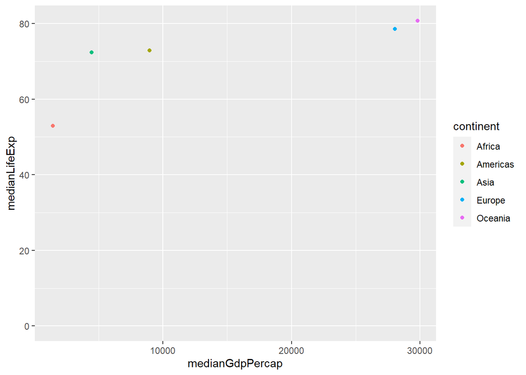

```r
# Summarize the median GDP and median life expectancy per continent in 2007
by_continent_2007 <- gapminder %>%
            filter(year == 2007) %>%
            group_by(continent) %>%
              summarize(medianGdpPercap = median(gdpPercap),
              medianLifeExp = median(lifeExp))

# Use a scatter plot to compare the median GDP and median life expectancy
ggplot(by_continent_2007, aes(x = medianGdpPercap, y = medianLifeExp, color = continent)) +
      geom_point() +
      expand_limits(y=0)
```

# SCATER VS LINE PLOT

Para criar o grafico de linhas, basta usar o comando *geom_line()*.

```r
by_year_continent <- gapminder %>%
                  group_by(year, continent) %>%
                  summarize(totalPop = sum(as.numeric(pop)),
                  meanLifeExp = mean(lifeExp))
```

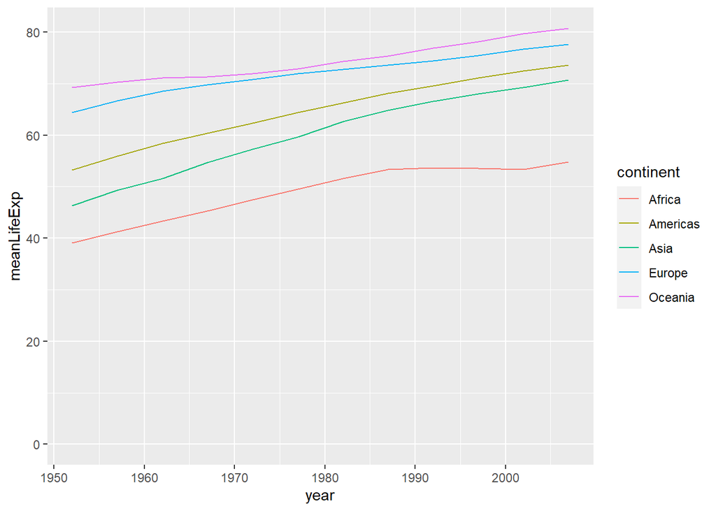

```r
ggplot(by_year_continent, aes(x = year, y = meanLifeExp, color = continent)) + geom_line() +
  expand_limits(y = 0)
```

Exercicio

Use group_by() and summarize() to find the median GDP per capita within each year, calling the output column medianGdpPercap. Use the assignment operator <- to save it to a dataset called by_year.

Use the by_year dataset to create a line plot showing the change in median GDP per capita over time. Be sure to use expand_limits(y = 0) to include 0 on the y-axis.

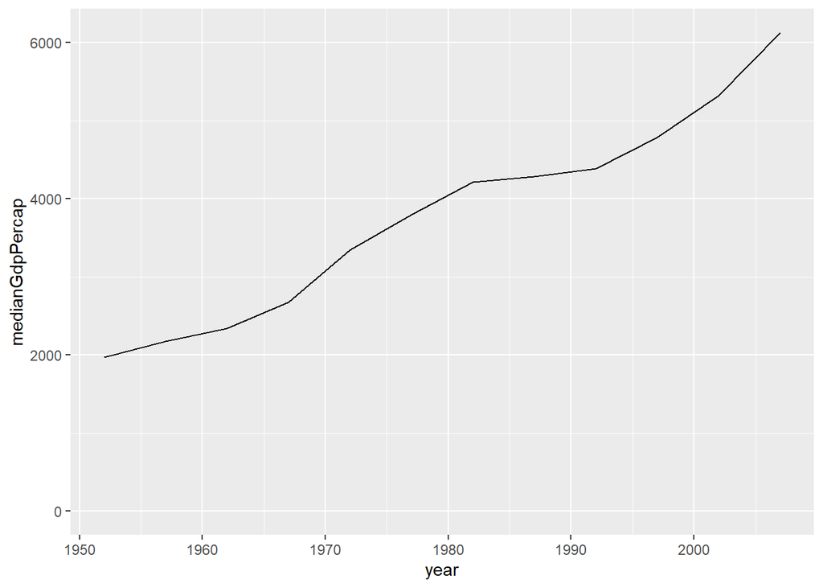

```r
# Summarize the median gdpPercap by year, then save it as by_year
by_year <- gapminder %>%
                group_by(year) %>%
                summarize(medianGdpPercap = median(gdpPercap))

# Create a line plot showing the change in medianGdpPercap over time
ggplot(by_year, aes(x = year, y = medianGdpPercap)) +
          geom_line() +
          expand_limits(y=0)
```

Exercicio

Now you’ll examine the change within each continent.

Use group_by() and summarize() to find the median GDP per capita within each year and continent, calling the output column medianGdpPercap. Use the assignment operator <- to save it to a dataset called by_year_continent.

Use the by_year_continent dataset to create a line plot showing the change in median GDP per capita over time, with color representing continent. Be sure to use expand_limits(y = 0) to include 0 on the y-axis.

```r
# Summarize the median gdpPercap by year & continent, save as by_year_continent
by_year_continent <- gapminder %>%
                      group_by(year, continent) %>%
                      summarize(medianGdpPercap = median(gdpPercap))
```

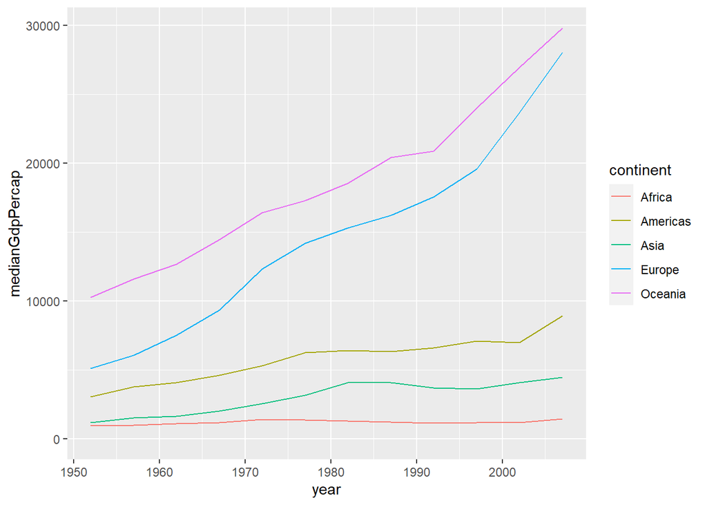

```r
# Create a line plot showing the change in medianGdpPercap by continent over time
ggplot(by_year_continent, aes(x = year, y = medianGdpPercap,
        color = continent)) +
        geom_line() +
        expand_limits(y = 0)
```

# BAR PLOTS - Grafico de barras

O graficos de barra sao uteis para voce comparar valores entre categorias distintas, como continentes.Por exemplo, vimos que para encontrar a expectativa de vida média em cada continente em 2007, precisamos do seguinte código. Ele criará uma tabela com uma observação para cada continente.

```r
by_continent_2007 <- gapminder %>%
            filter(year == 2007) %>%
            group_by(continent) %>%
              summarize(meanLifeExp = mean(lifeExp))

by_continent_2007
```

```
## # A tibble: 5 x 2
##   continent meanLifeExp
##   <fct>           <dbl>
## 1 Africa           54.8
## 2 Americas         73.6
## 3 Asia             70.7
## 4 Europe           77.6
## 5 Oceania          80.7
```

# Exercicio

Use group_by() and summarize() to find the median GDP per capita within each continent in the year 1952, calling the output column medianGdpPercap. Use the assignment operator <- to save it to a dataset called by_continent.

Use the by_continent dataset to create a bar plot showing the median GDP per capita in each continent.

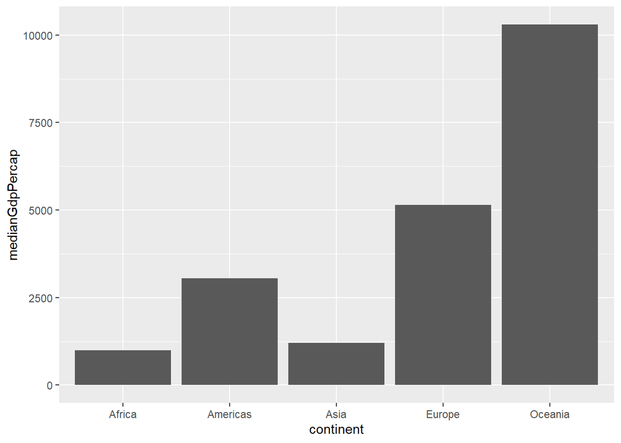

```r
# Summarize the median gdpPercap by continent in 1952
by_continent <- gapminder %>%
                filter(year == 1952) %>%
                group_by(continent) %>%
                summarize(medianGdpPercap = median(gdpPercap))

# Create a bar plot showing medianGdp by continent
ggplot(by_continent, aes(x = continent, y = medianGdpPercap)) +
      geom_col()
```

# Exercicio

*Visualizing GDP per capita by country in Oceania*

You’ve created a plot where each bar represents one continent, showing the median GDP per capita for each. But the x-axis of the bar plot doesn’t have to be the continent: you can instead create a bar plot where each bar represents a country.

In this exercise, you’ll create a bar plot comparing the GDP per capita between the two countries in the Oceania continent (Australia and New Zealand).

```r
# *Instruções*

# Filter for observations in the Oceania continent in the year 1952. Save this as oceania_1952.

# Use the oceania_1952 dataset to create a bar plot, with country on the x-axis and gdpPercap on the y-axis.
```

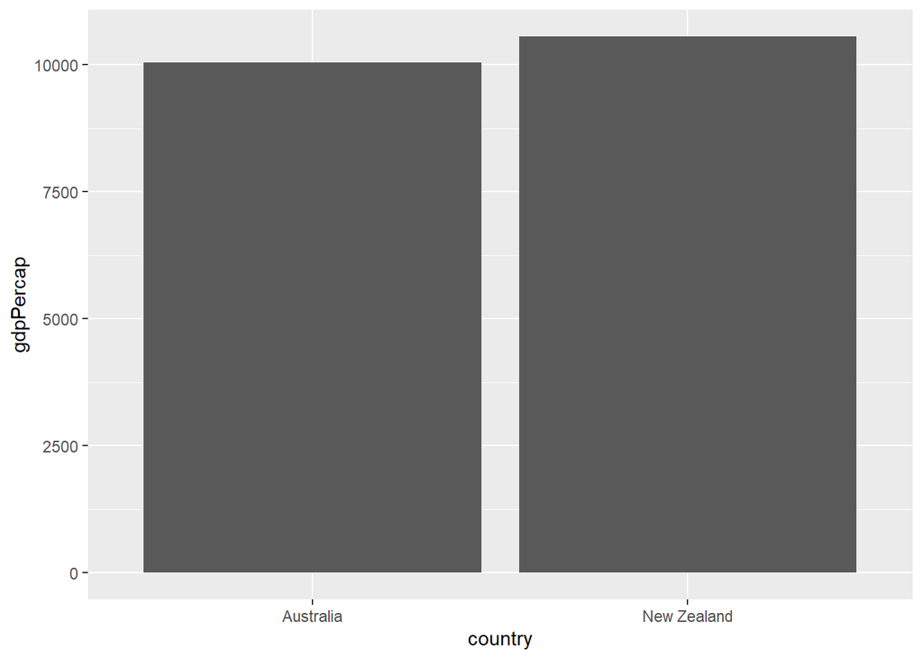

```r
# Filter for observations in the Oceania continent in 1952
oceania_1952 <- gapminder %>%
                filter(year == 1952, continent == "Oceania") %>%
                group_by(country, continent)

# Create a bar plot of gdpPercap by country
ggplot(oceania_1952, aes(x = country, y = gdpPercap)) +
        geom_col()
```